# Use Case “Insurance SCR” - Main effects

## 2.3 In sample vs. out of sample fit

Since calibration of linear models is fast and requires no intervention from the user, it is easy to perform a couple of them on different subsets to test stability and detect possible overfitting.

```r
# number of iterations
niter = 10
rsq = array(Inf, dim=c(niter,3), dimnames = list(NULL, c("out", "in", "delta")) )
for(iiter in 1:niter){
  # select the points in the design
  tmp = sample.int(nxtrain, 2 * dessize, replace = FALSE)
  idxtmp = tmp[1:dessize]
  xtmp = xtrain[idxtmp,]
  ytmp = ytrain[idxtmp]

  # test data for out-of-sample
  idxtest = tmp[-(1:dessize)]
  xtest = xtrain[idxtest,]
  ytest = ytrain[idxtest]

  # fit the model
  mdtmp = lm( ytmp ~ ., as.data.frame(cbind(ytmp, xtmp)))
  # calculate Rsquareds
  rsq[iiter,"in"] = 1 - mean((ytmp - mdtmp$fitted.values)^2) / var(ytmp)
  rsq[iiter, "out"] = 1 - mean((ytest - predict(mdtmp, as.data.frame(xtest)))^2) / var(ytest)
}

rsq[,"delta"] = rsq[, "out"] - rsq[,"in"]
rsq = rbind(rsq,colMeans(rsq))
row.names(rsq) = c(rep("",niter), "mean")
kable_styling(kable(rsq*100, digits = 1, caption = "In and out of sample $R^2$ for repeated model calibration"
          ), bootstrap_options = "striped", full_width = F)
```

Table 2.1: Table 2.2: In and out of sample $R2R2$ for repeated model calibration

|  | out | in | delta |
| --- | --- | --- | --- |
|  | 86.0 | 85.4 | 0.6 |
|  | 86.1 | 85.0 | 1.1 |
|  | 85.4 | 84.9 | 0.5 |
|  | 85.7 | 85.5 | 0.2 |
|  | 85.0 | 85.5 | -0.5 |
|  | 85.3 | 85.8 | -0.4 |
|  | 85.6 | 86.1 | -0.5 |
|  | 85.2 | 85.9 | -0.7 |
|  | 85.5 | 84.4 | 1.1 |
|  | 86.0 | 85.8 | 0.2 |
| mean | 85.6 | 85.4 | 0.2 |

In conclusion, no overfitting is apparent. For this reason we do not need to distinguish between in and out of sample statistics for this model. Solely for reasons of simplicity the remainder of this first report will use only in sample statistics.

## 2.4 Standardised regression coefficients

Linear models are sometimes deemed inherently interpretable because the model structure is simple and easily accessible. It is natural to use this knowledge to explain the effects of the features on the outcome. The main effects model is the sum of $βixiβixi$ so a natural candidate for the effect size of theses terms is their normalised variance, i.e. the [standardised regression coefficients](https://en.wikipedia.org/wiki/Standardized_coefficient) defined as

The following chart shows the decomposition for the 13 variables $X1,…,XdX1,…,Xd$ involved.

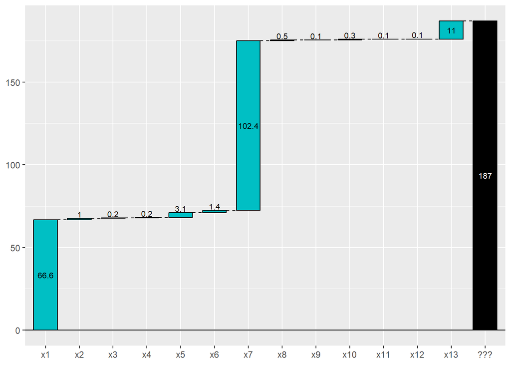

Figure 2.2: “Decomposition” using squared standardised regression coefficients

```r
# empirical variance of the inputs
var_x = apply(x, 2, var)
# standard(ised) regression coefficients
stdregcf = cf^2 * var_x / var_y

df = data.frame(values = round(c(stdregcf) * 100,1),
                labels=c(names(stdregcf)) )
p = waterfall( df, calc_total = TRUE, total_axis_text = "???")
print(p)
```

This “decomposition” has the obvious problem that the terms do not add up to 100%. While this could be easily fixed (or fudged?) by simply rescaling the sum to 100%, it is important to appreciate the underlying reason for the issue. The reason the terms don’t sum up to 100% is the correlation between the variables: The variance of a sum is equal to the sum of variances only if variables are uncorrelated. This is not the case here as was shown in Section 1.4.2. In fact standardised regression coefficients are pure marginal statistics and ignore completely any dependence between the input variables. Given that $x1x1$ and $x7x7$ are strongly negative correlated the stand alone impact on variance of either one is highly inflated. This is because any change in one variable will be countered by some corresponding change in opposite direction of the other variable thus partially cancelling their joint impact on the variance. As a consequence this approach seems only valid for uncorrelated input variables.

## 2.5 Permutation feature importance

While standard regression coefficients have been around since the last century, permutation feature importance was first published 2001 and is a very popular approach in machine learning. See [Section 8.5.1](https://christophm.github.io/interpretable-ml-book/feature-importance.html) of [Molnar] or [Section 4.2](https://scikit-learn.org/stable/modules/permutation_importance.html) of [SciKit-learn].

Although permutation feature importance is readily available in many machine learning packages it is simple enough to be reprogrammed from scratch below. The main idea is to measure the average increase in error when the model is evaluated on data points where the value of a feature is permuted. Since it is not feasible to calculate all permutations the average is approximated by Monte-Carlo. A careful analysis of the code below or the description of the algorithm reveals that the method is indeed model-agnostic, i.e. it just relies on a model’s `predict` method. Solely for reasons of speed the code below does not use the `predict` method of the respective `md` object but does the evaluation explicitly by performing the matrix multiplication.

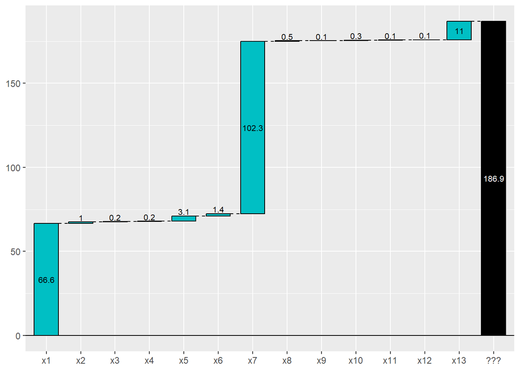

Figure 2.3: “Decomposition” using permutation feature importance

```r
# unperturbed loss
pred_orig = md$coefficients[1] + x %*% cf
loss_orig = sum((y - pred_orig)^2)

# number of MC iterations
niter = 1000
# store for cumulated errors
err = rep(0, nrf)
# loop over features
for(ifeat in 1:nrf){
  # calculate the constant part and don't forget the intercept
  pred_noni = md$coefficients[1] + x[,-ifeat] %*% cf[-ifeat]
  # MC loop
  for(iiter in 1:niter){
    perm = sample.int(dessize)
    # include the permuted feature in the model's prediction
    pred_neu = pred_noni + cf[ifeat] * x[perm,ifeat]
    # increase in loss due to permuted features
    delta_mse = sum((y - pred_neu)^2) - loss_orig
    err[ifeat] = err[ifeat] + delta_mse
  }
}

# normalise err
err = err / var_y / 2 / (dessize - 1) / niter

df = data.frame(values = round(c(err) * 100,1),
                labels=c(nm_x) )
print(waterfall( df, calc_total = TRUE, total_axis_text = "???") )
```

Comparison with the prior chart reveals, that, indeed, for the linear model permutation feature importance is identical to standardised regression coefficients up to a constant factor of two. But this means that the same caveats apply to the analysis based on permutation feature importance as they apply to standardised regression coefficients. Furthermore, the fact that permutation destroys the underlying dependence structure of features should not come as a surprise to any user and is not limited to the linear model or the squared error loss.[^3]

## 2.6 New features

### 2.6.1 Block allocation

Since most input variables of our use case are uncorrelated and the trouble is caused only by some few variables, one way to work around the problem may be to treat those troublesome features as a single block. This block as a whole then gets variance allocated together with all other uncorrelated variables. It was shown in 1.4.2 that only the variables $xixi$ with $i∈{1,2,3,7}i∈{1,2,3,7}$ are correlated. We introduce a new variable

and calculate the standardised regression coefficients for the new variable $zz$ and the rest.

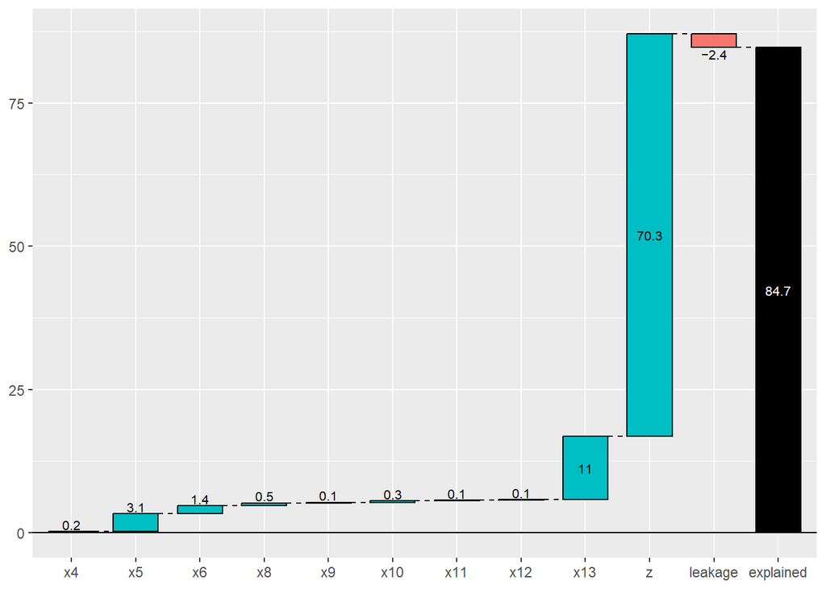

Figure 2.4: Attribution of variance on blocks of inputs

```r
# detect variables with non-trivial correlation
eps = 1/100
cormat = cor(xtrain)
idx = lower.tri(cormat)
# flag those pairs with absolute correlation larger than the eps-threshold
idx_tmp = which(abs(cormat) > eps, arr.ind = TRUE)
flg = idx_tmp[,1] < idx_tmp[,2]
idx_ntcorr = idx_tmp[flg,,drop=FALSE]
# the correlated variables
idx_c = unique(c(idx_ntcorr))
# the complement, i.e. the uncorrelated ones
idx_nc = seq.int(1,nrf)[-idx_c]

# define new variable from correlated variables
zblock = x[,idx_c] %*% cf[idx_c]
src_zblock = var(zblock) / var_y
src_other = cf[idx_nc]^2 * var_x[idx_nc] / var_y
leakage = relvar_f - (src_zblock + sum(src_other) )

df = data.frame(values = round(c(src_other, src_zblock, leakage) * 100,1),
                labels=c(names(src_other), "z", "leakage"))
print(waterfall( df, calc_total = TRUE, total_axis_text = "explained"))
```

The good news is that now the variances almost sum up to the variance of $ff$ which is 84.7%. The small difference, which is called leakage in the graph, is due to sampling error. When measured with the full dataset containing 32768 items, the correlations between zblock and the rest are close to zero. This is no longer true when using the smaller size of 4000 as was done here. This fact can be easily verified using the full training set, as is done below.

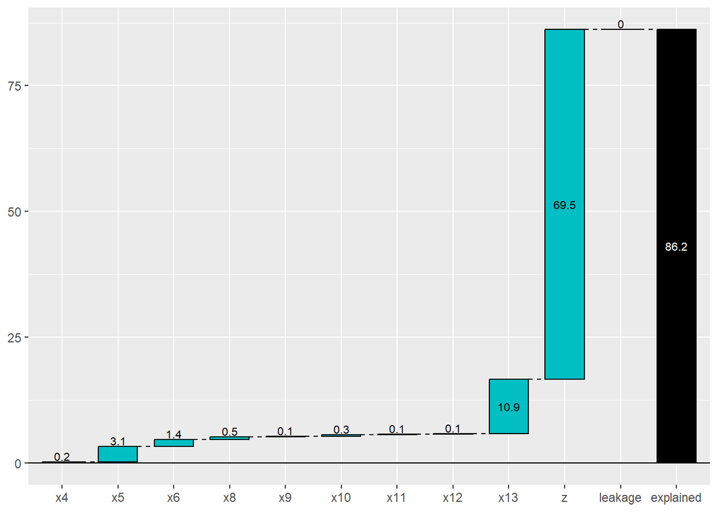

Figure 2.5: No leakage on the full dataset

```r
# variance split on the whole dataset
varall_x = apply(xtrain, 2, var)
src_zblockall = var(xtrain[,idx_c] %*% cf[idx_c]) / var_y
src_allother = cf[idx_nc]^2 * varall_x[idx_nc] / var_y
relvar_fall = var(xtrain %*% cf) / var_y
leakage = relvar_fall - (src_zblockall + sum(src_allother) )
df = data.frame(values = round(c(src_allother, src_zblockall, leakage) * 100,1),
                labels=c(names(src_other), "z", "leakage"))
print(waterfall( df, calc_total = TRUE, total_axis_text = "explained"))
```

Indeed, leakage is (sufficiently close to) zero when using all available data. Note that the variance of $ff$ (the right black bar “explained”) has changed from 84.7% to 86.2% since the dataset has changed.

But no matter which dataset we choose for calibration, the bad news remains. The block defined by $zz$ is by far the most important variable. We can peek into the block to see exactly how big the problem is, but still have no way of distributing the contribution from the correlation.

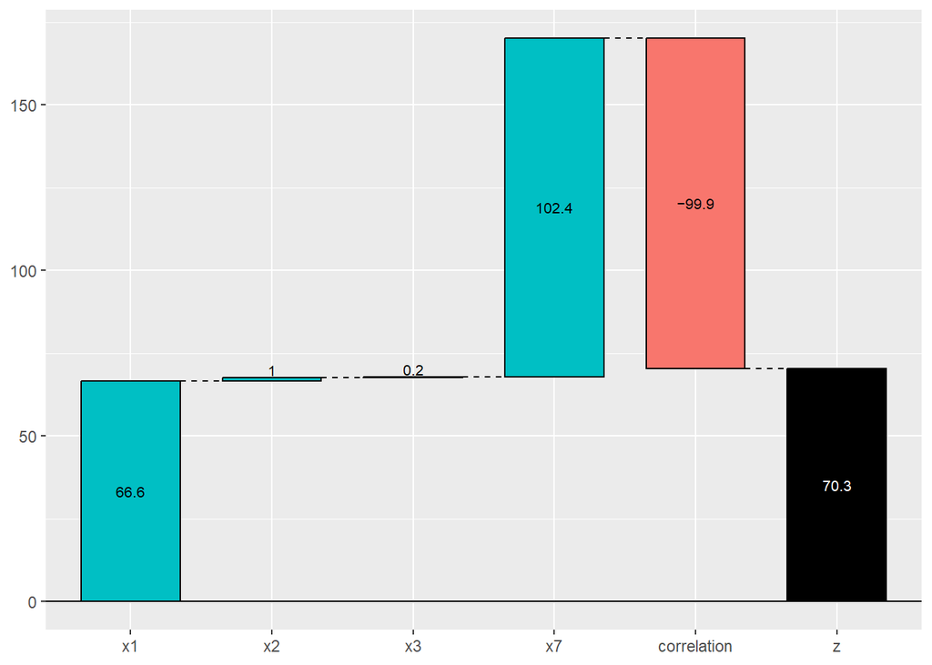

Figure 2.6: Incomplete variance attribution for the z-block

```r
# z-block break down

var_xinz = cf[idx_c]^2 * var_x[idx_c]
src_xinz = var_xinz / var_y
src_delta = src_zblock - sum(src_xinz)
df = data.frame(values = round(c(src_xinz, src_delta) * 100,1),
                labels=c(names(src_xinz), "correlation") )
print(waterfall( df, calc_total = TRUE, total_axis_text = "z"))
```